# Week 1 - Lecture 1

## Welcome to Algorithms & Programming!

- homeworks + exam
- Moodle forum
- no copy-pasting, no group work
- NO ChatGPT!!
- student participation !!!

## R

- toolbox for statistical analyses and data manipulation
- advanced, flexible data formats
- user-friendly
- simple syntax
- packages
- community: documentation, stackOverflow, Github, Biostars…

## Make your R usage easier

### Tips&Tricks

- Ctrl+Enter to run code/send to console
- tab for auto-complete
- keyboard shortcuts listed in *Help*
- History: send to console, up arrow
- Help: search manually or from console (?, ??, example())
- adjust defaults in Global options

## Make your R usage easier

### Rmarkdown (https://rmarkdown.rstudio.com/)

- various outputs for sharing your work (.html, .pdf, Word, website…)
- text + code chunks
- `Ctrl+Alt+I` to insert new chunk
- chunk options (message, warning, fig…)

## Make your R usage easier

### User interfaces

1. RGui - useful when upgrading versions (package *installR*)
2. RStudio - additional functionality, projects

## Basic components

- variables
- functions
- environment

For starters, you can use R as a calculator:

```r
3 + 5
10/2
4^2
8 %/% 3
8 %% 3
```

```
[1] 8
[1] 5
[1] 16
[1] 2
[1] 2
```

Some basic functions:

```r
round(1.86)
sqrt(25)
log10(1000)
```

```
[1] 2
[1] 5
[1] 3
```

## Variables

- everything is a vector
- assignment:
  - **`<-`**
  - `<<-`
  - `=`
  - but don’t touch the last two!!!
  - `n <- 5`
- create/collate: `c()`
- view: `print()` or type name

## Vectors

- character, numeric (integer and double), logical
- `class(), typeof()`
- `as.x()` family of functions

Create your first variable:

```r
n <- 9
```

Let’s see it:

```r
n
print(n)
class(n)
```

```
[1] 9
[1] 9
[1] "numeric"
```

As we said, every variable in R is a vector. So what does this mean?

Let’s add one more number to our variable n using function c():

```r
n <- c(n, 16); n
class(n)
```

```
[1]  9 16
[1] "numeric"
```

How do functions work on this?

```r
sqrt(n)
```

```
[1] 3 4
```

What happens when we try to add a letter?

```r
n <- c(n, "z"); n
class(n)
```

```
[1] "9"  "16" "z"
[1] "character"
```

**Numeric vector:**

```r
n1 <- c(1,2,4); n1
as.character(n1)
```

```
[1] 1 2 4
[1] "1" "2" "4"
```

Create sequential numeric vector:

```r
n2 <- 1:10; n2
```

```
 [1]  1  2  3  4  5  6  7  8  9 10
```

**Character vector:**

```r
ch <- c("a", "b", "c", "d", "spanishinquisition"); ch
```

```
[1] "a"                  "b"                  "c"
[4] "d"                  "spanishinquisition"
```

## Boolean variable

**TRUE FALSE**

It is a binary variable.

```r
bool <- c(T,F,T,T,F); bool
```

```
[1]  TRUE FALSE  TRUE  TRUE FALSE
```

```r
as.numeric(bool)
```

```
[1] 1 0 1 1 0
```

```r
bin <- c(0,1,1,0,1); bin
```

```
[1] 0 1 1 0 1
```

```r
class(bin)
```

```
[1] "numeric"
```

```r
as.logical(bin)
```

```
[1] FALSE  TRUE  TRUE FALSE  TRUE
```

## Boolean operators

- **AND** `&`
- **OR** `|`
- **NOT** `!`

```r
print(bool)
```

```
[1]  TRUE FALSE  TRUE  TRUE FALSE
```

```r
print(bin)
```

```
[1] 0 1 1 0 1
```

1. **&** and **|** are vectorised
2. **&&** and **||** are short-circuited

```r
bool & bin
bool && bin
```

```r
bool | bin
bool || bin
```

```r
!bool
!bool || bin
```

### Comparison operators

**==**

**!=**

**>**

**>=**

**<**

**<=**

```r
n2
```

```
 [1]  1  2  3  4  5  6  7  8  9 10
```

```r
n2 == 2
```

```
 [1] FALSE  TRUE FALSE FALSE FALSE FALSE FALSE FALSE FALSE FALSE
```

```r
n2 > 5
```

```
 [1] FALSE FALSE FALSE FALSE FALSE  TRUE  TRUE  TRUE  TRUE  TRUE
```

```r
n2 >= 5
```

```
 [1] FALSE FALSE FALSE FALSE  TRUE  TRUE  TRUE  TRUE  TRUE  TRUE
```

### Comparison operators

```r
bool
bin
```

```
[1]  TRUE FALSE  TRUE  TRUE FALSE
[1] 0 1 1 0 1
```

```r
bool == bin
```

```
[1] FALSE FALSE  TRUE FALSE FALSE
```

```r
bool != bin
```

```
[1]  TRUE  TRUE FALSE  TRUE  TRUE
```

### RECYCLING

What happens when vectors are not the same length?

```r
n1; n2
```

```
[1] 1 2 4
```

```
 [1]  1  2  3  4  5  6  7  8  9 10
```

```r
n2*c(2,3)
```

```
 [1]  2  6  6 12 10 18 14 24 18 30
```

```r
n2*n1
n2 == n1
```

```
 [1]  1  4 12  4 10 24  7 16 36 10
 [1]  TRUE  TRUE FALSE FALSE FALSE FALSE FALSE FALSE FALSE FALSE
```

## Basic functions

`length()` : how many elements in a vector

```r
myvec <- 1:20
length(myvec)
```

```
[1] 20
```

```r
length("banana")
nchar("banana")
```

```
[1] 1
[1] 6
```

`which()` : returns positions of elements which satisfy the condition

```r
which(n1 == 4)
which((myvec<=2) | (myvec>17))
```

```
[1] 3
[1]  1  2 18 19 20
```

## Basic functions

`names()` : gives names to the elements

```r
names(ch) <- c("letter", "letter", "letter", "anotherletter", "nobodyexpected")
ch
```

```
              letter               letter               letter
                 "a"                  "b"                  "c"
       anotherletter       nobodyexpected
                 "d" "spanishinquisition"
```

`%in%` operator - are elements of the first vector present in the second vector?

```r
n2 %in% n1
```

```
 [1]  TRUE  TRUE FALSE  TRUE FALSE FALSE FALSE FALSE FALSE FALSE
```

## Basic functions

`unique()` : returns unique elements

```r
n3 <- c(0,0,0,0,1,1,1,2,2,2,2,2,3,3,3,3,5)
unique(n3)
```

```
[1] 0 1 2 3 5
```

`duplicated()` : logical: did the same element appear before in the vector?

```r
duplicated(n3)
duplicated(c(5, n3))
```

```
 [1] FALSE  TRUE  TRUE  TRUE FALSE  TRUE  TRUE FALSE  TRUE  TRUE  TRUE  TRUE
[13] FALSE  TRUE  TRUE  TRUE FALSE
 [1] FALSE FALSE  TRUE  TRUE  TRUE FALSE  TRUE  TRUE FALSE  TRUE  TRUE  TRUE
[13]  TRUE FALSE  TRUE  TRUE  TRUE  TRUE
```

`table()` : how many times does each unique element appear

```r
table(n3)
```

```
n3
0 1 2 3 5
4 3 5 4 1
```

Get just the frequencies from table:

```r
n3
as.numeric(table(n3))
```

```
 [1] 0 0 0 0 1 1 1 2 2 2 2 2 3 3 3 3 5
[1] 4 3 5 4 1
```

Get unique elements using names - but be careful!

```r
names(table(n3))
class(names(table(n3)))
```

```
[1] "0" "1" "2" "3" "5"
[1] "character"
```

### Taking a sample

`sample()` : take a sample from vector

```r
sample(n3, 4)
sample(n3, 25, replace=TRUE)
```

```
[1] 1 1 2 2
 [1] 1 3 3 3 3 2 3 1 3 3 5 0 3 2 3 0 1 0 0 0 1 2 3 3 0
```

Take a sample from some basic distributions:

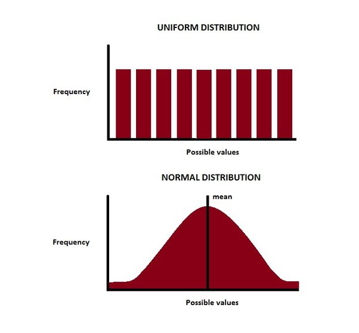

```r
sample(1:100, size = 10)
runif(10, min=1, max=100)
s <- rnorm(20, mean=3, sd=0.7); s
```

```
 [1] 62 67 16 68 26 24 92 44 88 96
 [1] 96.041517 66.758571  9.026198 16.081324 34.776095 43.891385 36.276125
 [8] 45.725790 59.153096 28.156006
 [1] 2.452289 3.428813 2.298833 3.498484 3.189722 3.060816 3.091299 2.592480
 [9] 2.377535 2.659415 3.815378 3.086934 2.620943 3.547611 3.901228 2.643391
[17] 2.823681 3.576900 2.167666 3.663854
```

### Generating sequences

`seq()`

```r
seq(from=1, to=100, by=2)
seq(from=0, to=10, length.out=21)
```

```
 [1]  1  3  5  7  9 11 13 15 17 19 21 23 25 27 29 31 33 35 37 39 41 43 45 47 49
[26] 51 53 55 57 59 61 63 65 67 69 71 73 75 77 79 81 83 85 87 89 91 93 95 97 99
 [1]  0.0  0.5  1.0  1.5  2.0  2.5  3.0  3.5  4.0  4.5  5.0  5.5  6.0  6.5  7.0
[16]  7.5  8.0  8.5  9.0  9.5 10.0
```

`rep()`

```r
rep(1:3, times=4)
rep(1:3, each=4)
```

```
 [1] 1 2 3 1 2 3 1 2 3 1 2 3
 [1] 1 1 1 1 2 2 2 2 3 3 3 3
```

don’t mix up `rep()` and `replicate()`!

```r
replicate(n = 10, expr = mean(sample(x = 1:10, size = 3)) )
```

```
 [1] 7.000000 6.000000 5.000000 7.333333 3.666667 3.666667 7.333333 6.666667
 [9] 6.333333 3.000000
```

### Basic statistics

```r
mean(s)
```

```
[1] 3.024863
```

```r
sd(s)
```

```
[1] 0.5371422
```

```r
quantile(s)
```

```
      0%      25%      50%      75%     100%
2.167666 2.613827 3.073875 3.510765 3.901228
```

## Vector subsetting []

1. **by position**
2. by condition

One position:

```r
n1[3]
```

```
[1] 4
```

Multiple positions:

```r
n2[1:5]
ch[c(2,4,5)]
```

```
[1] 1 2 3 4 5
              letter        anotherletter       nobodyexpected
                 "b"                  "d" "spanishinquisition"
```

Everything except 1 position:

```r
n2[-7]
```

```
[1]  1  2  3  4  5  6  8  9 10
```

Positions stored in another vector:

```r
n2[n1]
```

```
[1] 1 2 4
```

## Vector subsetting []

1. by position
2. **by condition**

```r
n2
n2 > 5
n2[n2 > 5]
```

```
 [1]  1  2  3  4  5  6  7  8  9 10
 [1] FALSE FALSE FALSE FALSE FALSE  TRUE  TRUE  TRUE  TRUE  TRUE
[1]  6  7  8  9 10
```

```r
bin
n2[bin]
n2[as.logical(bin)]
```

```
[1] 0 1 1 0 1
[1] 1 1 1
[1]  2  3  5  7  8 10
```

#### Exercise 1

Create a vector myvec which contains all numbers from 1 to 20 except 3 and 6. Subset fifth and fourth number by position.

#### Exercise 2

Subset myvec to get only numbers smaller or equal to 2 or larger than 17. Return first the numbers, then their positions in the original vector.

Subset myvec to return only elements which are in positions divisible by 3.

#### Exercise 3

Return words from vector ch which have more than 5 letters.

## Data structures

```
- vectors
- factors = vectors with (unchangeable) levels
- matrices = dataframes with 1 type of data
- lists
- data frames = pretty lists
```

## Factors

Vectors with predefined levels.  
Usual suspects for your errors.

```r
fac <- factor(n3); fac
```

```
 [1] 0 0 0 0 1 1 1 2 2 2 2 2 3 3 3 3 5
Levels: 0 1 2 3 5
```

```r
fac[1] <- 6
fac
```

```
 [1] <NA> 0    0    0    1    1    1    2    2    2    2    2    3    3    3
[16] 3    5
Levels: 0 1 2 3 5
```

So how to turn a factor into normal numeric vector? There’s a hack.

```r
as.numeric(fac)
as.numeric(as.character(fac))
```

```
 [1] NA  1  1  1  2  2  2  3  3  3  3  3  4  4  4  4  5
 [1] NA  0  0  0  1  1  1  2  2  2  2  2  3  3  3  3  5
```

## Matrices

```r
m <- matrix(1:15, nrow=5, ncol=3); m
```

```
     [,1] [,2] [,3]
[1,]    1    6   11
[2,]    2    7   12
[3,]    3    8   13
[4,]    4    9   14
[5,]    5   10   15
```

Subsetting:

```r
m[1,3]
m[12]
m[,2]
```

```
[1] 11
[1] 12
[1]  6  7  8  9 10
```

Basic functions:

```r
t(m)      # transpose
diag(m)   # extract diagonal
dim(m)    # see dimensions
```

```
     [,1] [,2] [,3] [,4] [,5]
[1,]    1    2    3    4    5
[2,]    6    7    8    9   10
[3,]   11   12   13   14   15
[1]  1  7 13
[1] 5 3
```

#### Exercise 4

Make a 4x4 matrix m2 with numbers from 1 to 16. Let the first row be: 1 2 3 4 (hint: consult help with ?matrix).

Change all the numbers on the diagonal to zeroes.

Sum the elements in each row.

## Lists

Store anything; most flexible data type.

```r
l <- list(n2, bool, m, fac); l
```

```
[[1]]
 [1]  1  2  3  4  5  6  7  8  9 10

[[2]]
[1]  TRUE FALSE  TRUE  TRUE FALSE

[[3]]
     [,1] [,2] [,3]
[1,]    1    6   11
[2,]    2    7   12
[3,]    3    8   13
[4,]    4    9   14
[5,]    5   10   15

[[4]]
 [1] <NA> 0    0    0    1    1    1    2    2    2    2    2    3    3    3
[16] 3    5
Levels: 0 1 2 3 5
```

## Lists

Let’s name the entries:

```r
names(l) <- c("vector1", "vector2", "matrix1", "factor1")
```

How many entries?

```r
length(l)
```

```
[1] 4
```

How about dimensions?

```r
dim(l)
```

### List subsetting

By position:

```r
l[2]
class(l[2])
```

```
$vector2
[1]  TRUE FALSE  TRUE  TRUE FALSE

[1] "list"
```

By position, another way:

```r
l[[4]]
class(l[[4]])
```

```
 [1] <NA> 0    0    0    1    1    1    2    2    2    2    2    3    3    3
[16] 3    5
Levels: 0 1 2 3 5
[1] "factor"
```

By name:

```r
l$vector2
class(l$vector2)
l[["factor1"]]
```

```
[1]  TRUE FALSE  TRUE  TRUE FALSE
[1] "logical"
 [1] <NA> 0    0    0    1    1    1    2    2    2    2    2    3    3    3
[16] 3    5
Levels: 0 1 2 3 5
```

Subset an element of an element:

```r
unlist(l[2])
```

```
vector21 vector22 vector23 vector24 vector25
    TRUE    FALSE     TRUE     TRUE    FALSE
```

```r
class(unlist(l[2]))
```

```
[1] "logical"
```

```r
l[3]
```

```
$matrix1
     [,1] [,2] [,3]
[1,]    1    6   11
[2,]    2    7   12
[3,]    3    8   13
[4,]    4    9   14
[5,]    5   10   15
```

```r
l[[3]][2,3]
```

```
[1] 12
```

```r
#l[3][2,3]
```

## Data frames

“Matrices” with different types of data.

```r
df <- data.frame(m, ch); df
```

| X1 | X2 | X3 | ch |
| --- | --- | --- | --- |
| 1 | 6 | 11 | a |
| 2 | 7 | 12 | b |
| 3 | 8 | 13 | c |
| 4 | 9 | 14 | d |
| 5 | 10 | 15 | spanishinquisition |

```r
dim(df)
```

```
[1] 5 4
```

```r
ncol(df); nrow(df)
```

```
[1] 4
```

```
[1] 5
```

```r
colnames(df); rownames(df)
```

```
[1] "X1" "X2" "X3" "ch"
```

```
[1] "1" "2" "3" "4" "5"
```

### Data frame subsetting

By position:

```r
df[2, 3]
df[, 3:4]
```

```
[1] 12
```

| X3 | ch |
| --- | --- |
| 11 | a |
| 12 | b |
| 13 | c |
| 14 | d |
| 15 | spanishinquisition |

By names:

```r
df["ch"]
df$ch
class(df["ch"])
class(df$ch)
```

| ch |
| --- |
| a |
| b |
| c |
| d |
| spanishinquisition |

```
[1] "a"                  "b"                  "c"
[4] "d"                  "spanishinquisition"
[1] "data.frame"
[1] "character"
```

Internally, data frames are lists with entries of equal lengths.

## Data frames

Adding a column:

```r
df <- cbind(df, bool); df
```

| X1 | X2 | X3 | ch | bool |
| --- | --- | --- | --- | --- |
| 1 | 6 | 11 | a | TRUE |
| 2 | 7 | 12 | b | FALSE |
| 3 | 8 | 13 | c | TRUE |
| 4 | 9 | 14 | d | TRUE |
| 5 | 10 | 15 | spanishinquisition | FALSE |

Removing a column:

```r
df["bool"] <- NULL; df
```

| X1 | X2 | X3 | ch |
| --- | --- | --- | --- |
| 1 | 6 | 11 | a |
| 2 | 7 | 12 | b |
| 3 | 8 | 13 | c |
| 4 | 9 | 14 | d |
| 5 | 10 | 15 | spanishinquisition |

Removing a row:

```r
#df[5, ] <- NULL; df

df <- df[-5, ]
```

#### Exercise 5

R has a number of pre-loaded datasets, `iris` probably being the most famous one.

Load iris and calculate mean length of sepal.